# Painter’s Plot Functions Example

Before starting, remember to run all the code in the PPFunctions.R file. This will make all the Painter’s Plot functions available to you in R.

## Data Format

In your dataset, each row should represent a microbe and each column should represent a subject. The data can be raw count data, or proportional data by subject. Raw format data will allow for greater flexibility.

Let’s generate some simple data that fulfill these requirements and allow us to explore the Painter’s Plot functions:

```r
set.seed(1) #set random number generator
data <- matrix(round(runif(60, 1, 1000), 2), 10, 6)
rownames(data) <- paste("Microbe", letters[1:10])
colnames(data) <- paste("Subject", 1:6)
```

Let’s get a look at our data, which has 10 microbes (rows) and 6 subjects (columns):

```r
data
```

```
##           Subject 1 Subject 2 Subject 3 Subject 4 Subject 5 Subject 6
## Microbe a    266.24    206.77    934.77    482.60    821.13    478.14
## Microbe b    372.75    177.38    212.93    599.97    647.41    861.35
## Microbe c    573.28    687.34    652.02    494.05    783.15    438.66
## Microbe d    908.30    384.72    126.43    187.03    553.48    245.55
## Microbe e    202.48    770.07    267.95    827.55    530.19     71.61
## Microbe f    898.49    498.20    386.73    668.80    789.57    100.37
## Microbe g    944.73    717.90     14.38    794.45     24.31    316.96
## Microbe h    661.14    991.91    383.01    108.84    477.75    519.12
## Microbe i    629.48    380.66    869.82    723.99    732.58    662.34
## Microbe j     62.72    777.67    341.01    411.86    693.04    407.42
```

#### Summarize data

Let’s get a sense of the data, by using the *getSummary()* function:

```r
getSummary(data)
```

```
##                 Mean     Median         Min       Max         SD
## Microbe a 0.10861107 0.10382384 0.036971938 0.2231461 0.06782137
## Microbe b 0.09671174 0.08724786 0.031716798 0.2100075 0.06386625
## Microbe c 0.11866425 0.11492592 0.093232109 0.1556487 0.02237833
## Microbe d 0.07502296 0.06432935 0.030181067 0.1645587 0.04928285
## Microbe e 0.08326087 0.07578065 0.017459381 0.1561668 0.05507933
## Microbe f 0.10421902 0.10926421 0.024471415 0.1627814 0.04760603
## Microbe g 0.08902881 0.10282213 0.003432759 0.1711588 0.07306487
## Microbe h 0.10243529 0.10560572 0.020539182 0.1773605 0.05268289
## Microbe i 0.13481604 0.12882972 0.068064700 0.2076414 0.04710673
## Microbe j 0.08722995 0.09036950 0.011363122 0.1390529 0.04348800
```

As we can see above, the mean, median, minimum, maximum, and standard deviation for each microbe is displayed.

Notice that this summary gives the results in proportions, rather than as expressed by the raw counts of our data. This standardizes the comparisions made between microbes.

#### Generate a Basic Painter’s Plot

To generate painter’s plots, we will need the *ggplot2* package. If you haven’t already installed the package, you will need to run the following command to install this package into R:

```r
install.packages("ggplot2")
```

Once you have the *ggplot2* package installed, you can load the package by running:

```r
library("ggplot2")
```

You only have to install any package in R once, but it will need to be loaded each new R session.

One quick tip: Make sure the *Plots* window in RStudio isn’t too small, otherwise you might get an error message when trying to display the plot.

Let’s generate a painter’s plot using our simple dataset:

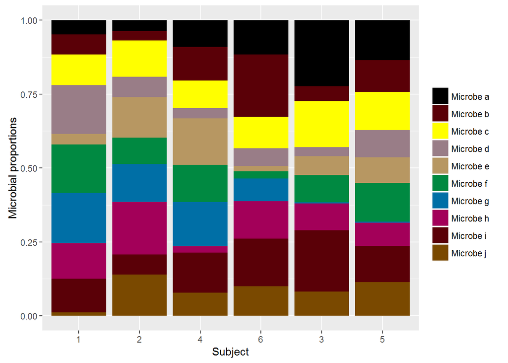

```r
PPlot(data)
```

#### Proportion vs. Raw Data

Notice that each bar in the plot above sums to 1. This is because, just like when we generated a summary of the data, the function automatically converts our raw data to proportions. If our data was already expressed in proportions, we can override this default:

```r
PPlot(data, prop = TRUE)
```

The *prop* is short for *proportion* and by setting it to TRUE (as opposed to FALSE) the function won’t convert our data to proprtions, becasue it is *TRUE* that our data is proportional.

We can do the same thing with our summary of our data if we want to stop the function from asssuming our data is in raw format:

```r
getSummary(data, prop = TRUE)
```

```
##               Mean  Median    Min    Max       SD
## Microbe a 531.6083 480.370 206.77 934.77 292.4254
## Microbe b 478.6317 486.360 177.38 861.35 269.1629
## Microbe c 604.7500 612.650 438.66 783.15 127.8381
## Microbe d 400.9183 315.135 126.43 908.30 291.9606
## Microbe e 444.9750 399.070  71.61 827.55 312.6836
## Microbe f 557.0267 583.500 100.37 898.49 291.2606
## Microbe g 468.7883 517.430  14.38 944.73 405.3967
## Microbe h 523.6283 498.435 108.84 991.91 293.9882
## Microbe i 666.4783 693.165 380.66 869.82 162.5441
## Microbe j 448.9533 409.640  62.72 777.67 257.5119
```

#### Group Subjects by Hierarchical Clustering Branches

Often we will want to group the subjects in our painter’s plot, which is done by hierarchical clustering. We may want to group our subjects by, say, the top 2 branches from hierarchical clustering. This is easy enough to do:

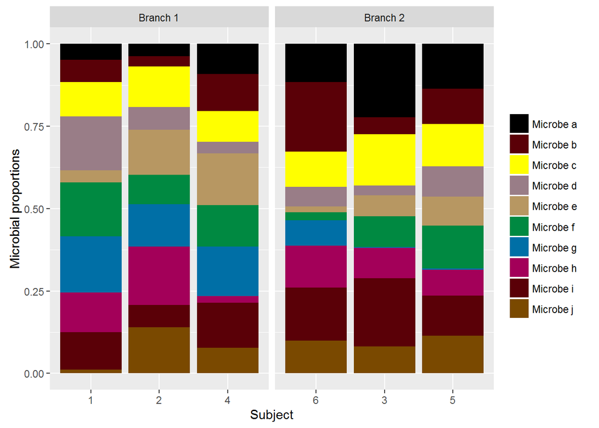

```r
PPlot(data, 2)
```

The second argument of this function is the number of branches to group subjects by. The following code would group the subjects by the top 5 branches:

```r
PPlot(data, 5)
```

#### Using Original Subject IDs

Let’s keep grouping subjects using the top two branches, and see what other options are available to us.

Notice that in our data our subject (column) names were *Subject 1*, *Subject 2*, etc., but now in the painter’s plot they are just numbered. We can get our original names back by altering our command:

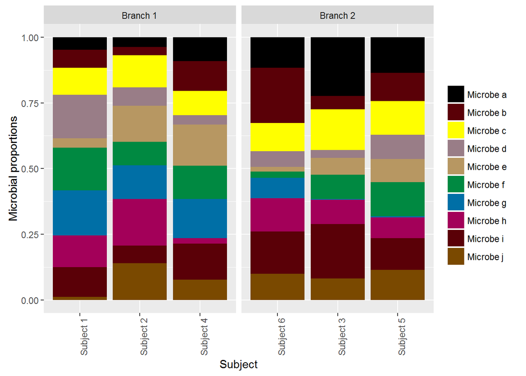

```r
PPlot(data, 2, subject_numbers = FALSE)
```

This prevents the function from numbering the subjects according to their order in the dataset. Using the original subject names turns the names vertical in the painter’s plot to avoid all the names from overlapping.

#### Omitting Microbes

What would this plot look like if we removed *Microbe b* from our data and then re-computed the proportions?

We can find out by adding the *omit* argument to our command:

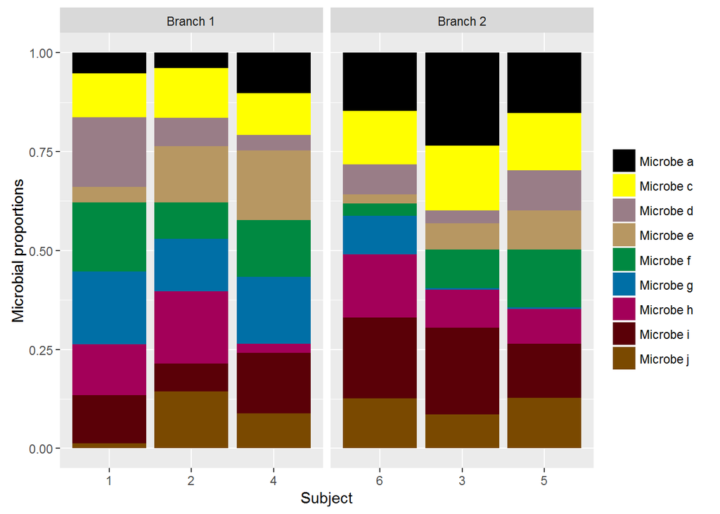

```r
PPlot(data, 2, omit = "Microbe b")
```

Notice that all the microbe colors stay the same even though we just removed a microbe. Also, the proportions for each subject are re-computed with *Microbe b* removed (hence, each bar sums to 1).

We can also use the *c()* which stands for *combine*, or *concatenate* to specify several microbes to omit from analysis:

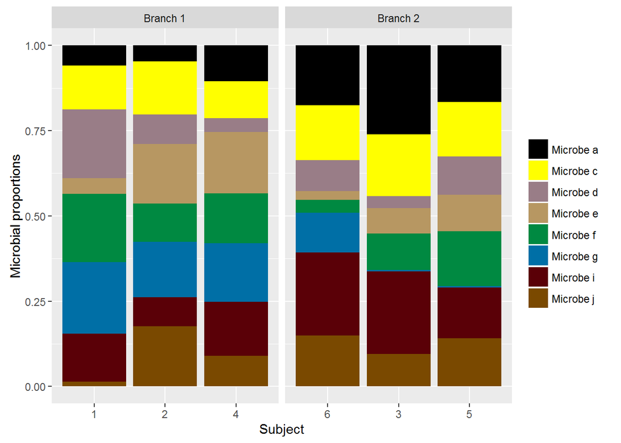

```r
PPlot(data, 2, omit = c("Microbe b", "Microbe h"))
```

#### Changing Deafult Colors

What if we wanted to change the default colors? We can do that by adding the *col* (short for *color*) argument to our command:

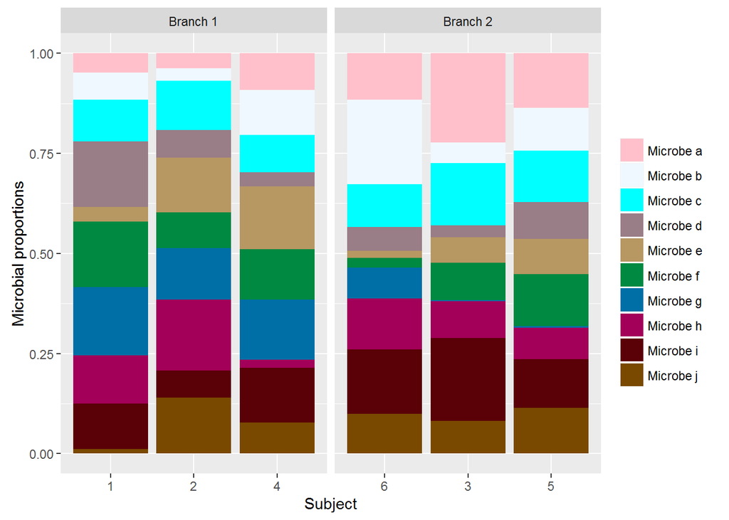

```r
PPlot(data, 2, col = c("pink", "aliceblue", "cyan"))
```

All the remaining colors are left unchanged. We can use any Hex Color Code (e.g. #000000 for black). Or we can get a list of all colors available by name in R using the following command:

```r
colors()
```

```
##  [1] "white"         "aliceblue"     "antiquewhite"  "antiquewhite1"
##  [5] "antiquewhite2" "antiquewhite3" "antiquewhite4" "aquamarine"
##  [9] "aquamarine1"   "aquamarine2"   "aquamarine3"   "aquamarine4"
## [13] "azure"         "azure1"        "azure2"        "..."
```

#### Changing the Hierarchical Clustering Distance Metric

So far, all the painter’s plot we have generated have been using the Euclidean (straight-line) distance for the distance metric for Hierarchical Clustering. But the *PPlot()* function has two other distance metrics available: Pearson Correlation and Spearman Rank Correlation. We can change the default Euclidean distance by using one of the commands below:

```r
PPlot(data, 2, dist = "pearson")
PPlot(data, 2, dist = "spearman")
```

### Putting it all together

Let’s put together the different elements of what we’ve been exploring. First, let’s generate a larger dataset:

```r
set.seed(1) #set random number generator
data <- matrix(round(runif(780, 1, 1000), 2), 26, 30)
rownames(data) <- paste("Microbe", letters[1:26])
colnames(data) <- paste("Subject", 1:30)
```

Let’s see what a painter’s plot for this data look like using the default arguments of the *PPlot()* function:

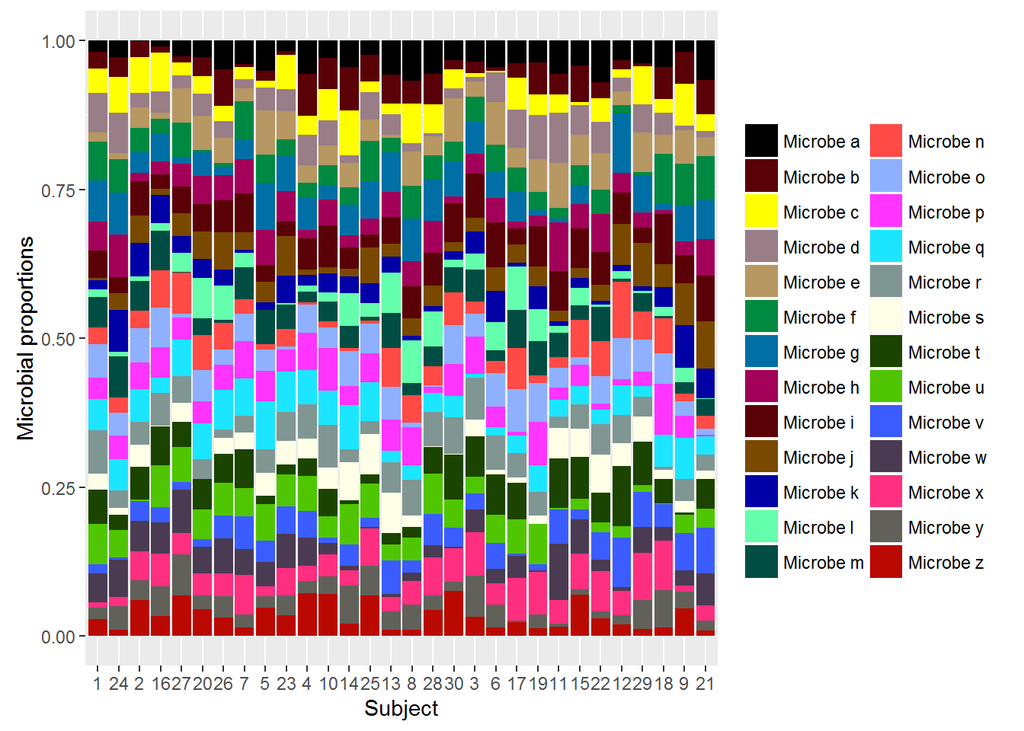

```r
PPlot(data)
```

Suppose we want to group subjects by the top 4 branches with their original IDs, use Pearson Corelation for our distance metric, as well as remove microbes a, s, and y. We can accomplish that will the following command:

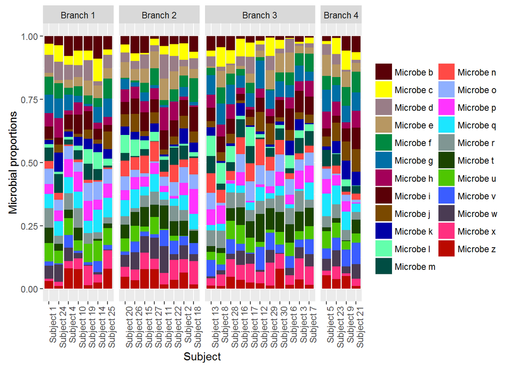

```r
PPlot(data, 4, subject_numbers = FALSE, dist = "pearson", omit = c("Microbe a", "Microbe s", "Microbe y"))
```

### Generate Shannon’s H Bar Plot

To generate a Shannon’s H Bar Plot, we will need the *vegan* package. If you haven’t already installed the package, you will need to run the following command to install this package into R:

```r
install.packages("vegan")
```

Once you have the *vegan* package installed, you can load the package by running:

```r
library("vegan")
```

In addition to our painter’s plot, often we want to include a bar chart showing each subject’s diversity. This can be accomplished using Shannon’s H. To generate Shannon’s H Bar Plot, we use the following command:

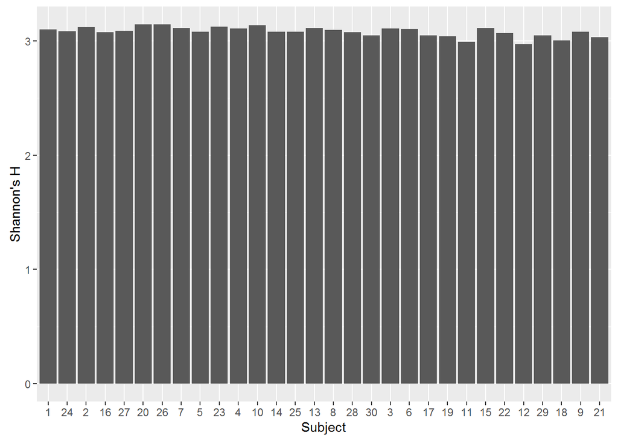

```r
shanH(data)
```

Because our data is generated using random numbers, we don’t get very much diversity across subjects.

But, notice that each subject is in the same order as the the painter’s plot with no subject groupings:

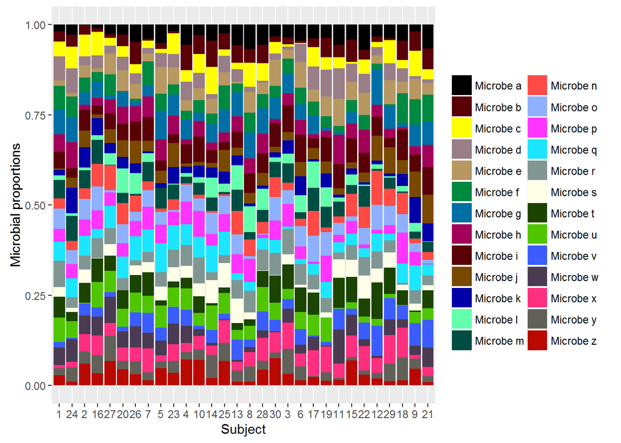

```r
PPlot(data)
```

To make our bar chart have the same subject groupings as our painter’s plot with 4 groupings above, we alter our command in the same way we did with the *PPlot()* function, where we used the top 4 branches, used Pearson’s Correlation, and omitted Microbes a, s, and y:

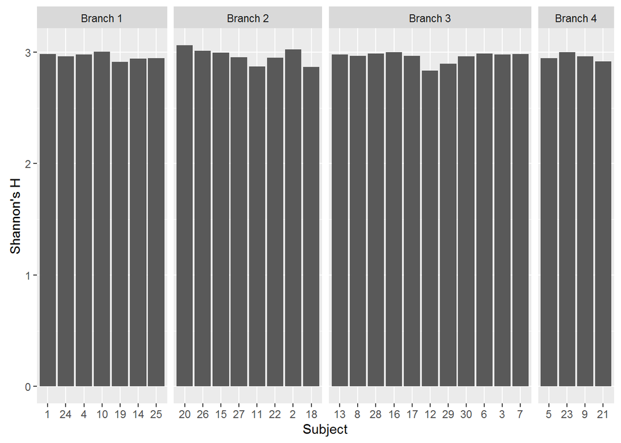

```r
shanH(data, 4, dist = "pearson", omit = c("Microbe a", "Microbe s", "Microbe y"))
```